# Risk Factor Analysis

## Outcome Variable

**Outcome Variable:** ever_co

## Predictor Variables

**Intervention Variable:** exclfeed36

**Adjustment Set:**

- arm
- sex
- brthmon
- W_mage
- meducyrs
- feducyrs
- hhwealth_quart
- hfoodsec
- W_mhtcm
- W_mwtkg
- W_mbmi
- vagbrth
- W_gagebrth
- W_birthwt
- W_birthlen
- W_nrooms
- W_nchldlt5
- month
- W_parity
- impfloor
- impsan
- safeh20
- delta_W_mage
- delta_meducyrs
- delta_feducyrs
- delta_hhwealth_quart
- delta_hfoodsec
- delta_W_mhtcm
- delta_W_mwtkg
- delta_W_mbmi
- delta_vagbrth
- delta_W_gagebrth
- delta_W_birthwt
- delta_W_birthlen
- delta_W_nrooms
- delta_W_nchldlt5
- delta_month
- delta_W_parity
- delta_impfloor
- delta_impsan
- delta_safeh20

## Stratifying Variables

The analysis was stratified on these variable(s):

- agecat
- studyid
- country

## Data Summary

| agecat | studyid | country | exclfeed36 | ever_co | n_cell | n |
| --- | --- | --- | --- | --- | --- | --- |
| 0-24 months | CMC-V-BCS-2002 | INDIA | 1 | 0 | 8 | 9 |
| 0-24 months | CMC-V-BCS-2002 | INDIA | 1 | 1 | 1 | 9 |
| 0-24 months | CMC-V-BCS-2002 | INDIA | 0 | 0 | 0 | 9 |
| 0-24 months | CMC-V-BCS-2002 | INDIA | 0 | 1 | 0 | 9 |
| 0-24 months | EE | PAKISTAN | 1 | 0 | 3 | 9 |
| 0-24 months | EE | PAKISTAN | 1 | 1 | 1 | 9 |
| 0-24 months | EE | PAKISTAN | 0 | 0 | 5 | 9 |
| 0-24 months | EE | PAKISTAN | 0 | 1 | 0 | 9 |
| 0-24 months | GMS-Nepal | NEPAL | 1 | 0 | 286 | 528 |
| 0-24 months | GMS-Nepal | NEPAL | 1 | 1 | 137 | 528 |
| 0-24 months | GMS-Nepal | NEPAL | 0 | 0 | 64 | 528 |
| 0-24 months | GMS-Nepal | NEPAL | 0 | 1 | 41 | 528 |
| 0-24 months | IRC | INDIA | 1 | 0 | 0 | 4 |
| 0-24 months | IRC | INDIA | 1 | 1 | 0 | 4 |
| 0-24 months | IRC | INDIA | 0 | 0 | 3 | 4 |
| 0-24 months | IRC | INDIA | 0 | 1 | 1 | 4 |
| 0-24 months | JiVitA-3 | BANGLADESH | 1 | 0 | 9001 | 12748 |
| 0-24 months | JiVitA-3 | BANGLADESH | 1 | 1 | 922 | 12748 |
| 0-24 months | JiVitA-3 | BANGLADESH | 0 | 0 | 2543 | 12748 |
| 0-24 months | JiVitA-3 | BANGLADESH | 0 | 1 | 282 | 12748 |
| 0-24 months | JiVitA-4 | BANGLADESH | 1 | 0 | 3010 | 4589 |
| 0-24 months | JiVitA-4 | BANGLADESH | 1 | 1 | 532 | 4589 |
| 0-24 months | JiVitA-4 | BANGLADESH | 0 | 0 | 834 | 4589 |
| 0-24 months | JiVitA-4 | BANGLADESH | 0 | 1 | 213 | 4589 |
| 0-24 months | Keneba | GAMBIA | 1 | 0 | 538 | 1983 |
| 0-24 months | Keneba | GAMBIA | 1 | 1 | 87 | 1983 |
| 0-24 months | Keneba | GAMBIA | 0 | 0 | 1103 | 1983 |
| 0-24 months | Keneba | GAMBIA | 0 | 1 | 255 | 1983 |
| 0-24 months | LCNI-5 | MALAWI | 1 | 0 | 44 | 272 |
| 0-24 months | LCNI-5 | MALAWI | 1 | 1 | 3 | 272 |

[output cut: 174 more lines]

The following strata were considered:

- agecat: 0-24 months, studyid: CMC-V-BCS-2002, country: INDIA
- agecat: 0-24 months, studyid: EE, country: PAKISTAN
- agecat: 0-24 months, studyid: GMS-Nepal, country: NEPAL
- agecat: 0-24 months, studyid: IRC, country: INDIA
- agecat: 0-24 months, studyid: JiVitA-3, country: BANGLADESH
- agecat: 0-24 months, studyid: JiVitA-4, country: BANGLADESH
- agecat: 0-24 months, studyid: Keneba, country: GAMBIA
- agecat: 0-24 months, studyid: LCNI-5, country: MALAWI
- agecat: 0-24 months, studyid: MAL-ED, country: BANGLADESH
- agecat: 0-24 months, studyid: MAL-ED, country: BRAZIL
- agecat: 0-24 months, studyid: MAL-ED, country: INDIA
- agecat: 0-24 months, studyid: MAL-ED, country: NEPAL
- agecat: 0-24 months, studyid: MAL-ED, country: PERU
- agecat: 0-24 months, studyid: MAL-ED, country: SOUTH AFRICA
- agecat: 0-24 months, studyid: MAL-ED, country: TANZANIA, UNITED REPUBLIC OF
- agecat: 0-24 months, studyid: PROVIDE, country: BANGLADESH
- agecat: 0-24 months, studyid: SAS-FoodSuppl, country: INDIA
- agecat: 0-6 months, studyid: CMC-V-BCS-2002, country: INDIA
- agecat: 0-6 months, studyid: EE, country: PAKISTAN
- agecat: 0-6 months, studyid: GMS-Nepal, country: NEPAL
- agecat: 0-6 months, studyid: IRC, country: INDIA
- agecat: 0-6 months, studyid: JiVitA-3, country: BANGLADESH
- agecat: 0-6 months, studyid: JiVitA-4, country: BANGLADESH
- agecat: 0-6 months, studyid: Keneba, country: GAMBIA
- agecat: 0-6 months, studyid: LCNI-5, country: MALAWI
- agecat: 0-6 months, studyid: MAL-ED, country: BANGLADESH
- agecat: 0-6 months, studyid: MAL-ED, country: BRAZIL
- agecat: 0-6 months, studyid: MAL-ED, country: INDIA
- agecat: 0-6 months, studyid: MAL-ED, country: NEPAL
- agecat: 0-6 months, studyid: MAL-ED, country: PERU
- agecat: 0-6 months, studyid: MAL-ED, country: SOUTH AFRICA
- agecat: 0-6 months, studyid: MAL-ED, country: TANZANIA, UNITED REPUBLIC OF
- agecat: 0-6 months, studyid: PROVIDE, country: BANGLADESH
- agecat: 0-6 months, studyid: SAS-FoodSuppl, country: INDIA
- agecat: 6-24 months, studyid: CMC-V-BCS-2002, country: INDIA
- agecat: 6-24 months, studyid: EE, country: PAKISTAN
- agecat: 6-24 months, studyid: GMS-Nepal, country: NEPAL
- agecat: 6-24 months, studyid: IRC, country: INDIA
- agecat: 6-24 months, studyid: JiVitA-3, country: BANGLADESH
- agecat: 6-24 months, studyid: JiVitA-4, country: BANGLADESH
- agecat: 6-24 months, studyid: Keneba, country: GAMBIA
- agecat: 6-24 months, studyid: LCNI-5, country: MALAWI
- agecat: 6-24 months, studyid: MAL-ED, country: BANGLADESH
- agecat: 6-24 months, studyid: MAL-ED, country: BRAZIL
- agecat: 6-24 months, studyid: MAL-ED, country: INDIA
- agecat: 6-24 months, studyid: MAL-ED, country: NEPAL
- agecat: 6-24 months, studyid: MAL-ED, country: PERU
- agecat: 6-24 months, studyid: MAL-ED, country: SOUTH AFRICA
- agecat: 6-24 months, studyid: MAL-ED, country: TANZANIA, UNITED REPUBLIC OF
- agecat: 6-24 months, studyid: PROVIDE, country: BANGLADESH
- agecat: 6-24 months, studyid: SAS-FoodSuppl, country: INDIA

### Dropped Strata

Some strata were dropped due to rare outcomes:

- agecat: 0-24 months, studyid: CMC-V-BCS-2002, country: INDIA
- agecat: 0-24 months, studyid: EE, country: PAKISTAN
- agecat: 0-24 months, studyid: IRC, country: INDIA
- agecat: 0-24 months, studyid: LCNI-5, country: MALAWI
- agecat: 0-24 months, studyid: MAL-ED, country: BANGLADESH
- agecat: 0-24 months, studyid: MAL-ED, country: BRAZIL
- agecat: 0-24 months, studyid: MAL-ED, country: INDIA
- agecat: 0-24 months, studyid: MAL-ED, country: NEPAL
- agecat: 0-24 months, studyid: MAL-ED, country: PERU
- agecat: 0-24 months, studyid: MAL-ED, country: SOUTH AFRICA
- agecat: 0-24 months, studyid: MAL-ED, country: TANZANIA, UNITED REPUBLIC OF
- agecat: 0-24 months, studyid: SAS-FoodSuppl, country: INDIA
- agecat: 0-6 months, studyid: CMC-V-BCS-2002, country: INDIA
- agecat: 0-6 months, studyid: EE, country: PAKISTAN
- agecat: 0-6 months, studyid: IRC, country: INDIA
- agecat: 0-6 months, studyid: LCNI-5, country: MALAWI
- agecat: 0-6 months, studyid: MAL-ED, country: BANGLADESH
- agecat: 0-6 months, studyid: MAL-ED, country: BRAZIL
- agecat: 0-6 months, studyid: MAL-ED, country: INDIA
- agecat: 0-6 months, studyid: MAL-ED, country: NEPAL
- agecat: 0-6 months, studyid: MAL-ED, country: PERU
- agecat: 0-6 months, studyid: MAL-ED, country: SOUTH AFRICA
- agecat: 0-6 months, studyid: MAL-ED, country: TANZANIA, UNITED REPUBLIC OF
- agecat: 0-6 months, studyid: PROVIDE, country: BANGLADESH
- agecat: 0-6 months, studyid: SAS-FoodSuppl, country: INDIA
- agecat: 6-24 months, studyid: CMC-V-BCS-2002, country: INDIA
- agecat: 6-24 months, studyid: EE, country: PAKISTAN
- agecat: 6-24 months, studyid: IRC, country: INDIA
- agecat: 6-24 months, studyid: LCNI-5, country: MALAWI
- agecat: 6-24 months, studyid: MAL-ED, country: BANGLADESH
- agecat: 6-24 months, studyid: MAL-ED, country: BRAZIL
- agecat: 6-24 months, studyid: MAL-ED, country: INDIA
- agecat: 6-24 months, studyid: MAL-ED, country: NEPAL
- agecat: 6-24 months, studyid: MAL-ED, country: PERU
- agecat: 6-24 months, studyid: MAL-ED, country: SOUTH AFRICA
- agecat: 6-24 months, studyid: MAL-ED, country: TANZANIA, UNITED REPUBLIC OF
- agecat: 6-24 months, studyid: SAS-FoodSuppl, country: INDIA

## Methods Detail

We’re interested in the causal parameters $E[Y_a]$ for all values of $a \in \mathcal{A}$. These parameters represent the mean outcome if, possibly contrary to fact, we intervened to set all units to have $A=a$. Under the randomization and positivity assumptions, these are identified by the statistical parameters $\psi_a=E_W[E_{Y|A,W}(Y|A=a,W)]$. In addition, we’re interested in the mean of $Y$, $E[Y]$ under no intervention (the observed mean). We will estimate these parameters by using SuperLearner to fit the relevant likelihood factors – $E_{Y|A,W}(Y|A=a,W)$ and $p(A=a|W)$, and then updating our likelihood fit using a joint TMLE.

For unadjusted analyses ($W=\{\}$), initial likelihoods were estimated using Lrnr_glm to estimate the simple $E(Y|A)$ and Lrnr_mean to estimate $p(A)$. For adjusted analyses, a small library containing Lrnr_glmnet, Lrnr_xgboost, and Lrnr_mean was used.

Having estimated these parameters, we will then use the delta method to estimate relative risks and attributable risks relative to a prespecified baseline level of $A$.

# Results Detail

## Results Plots

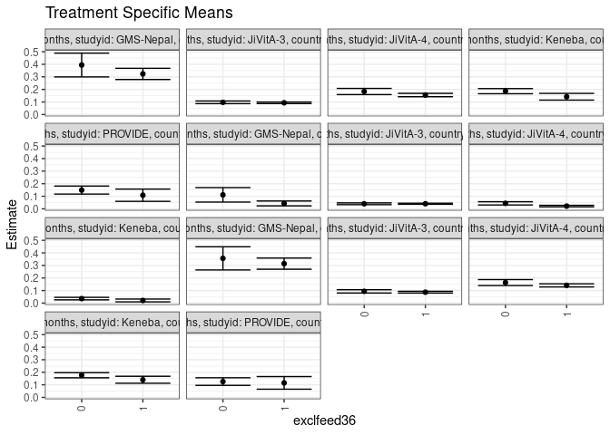

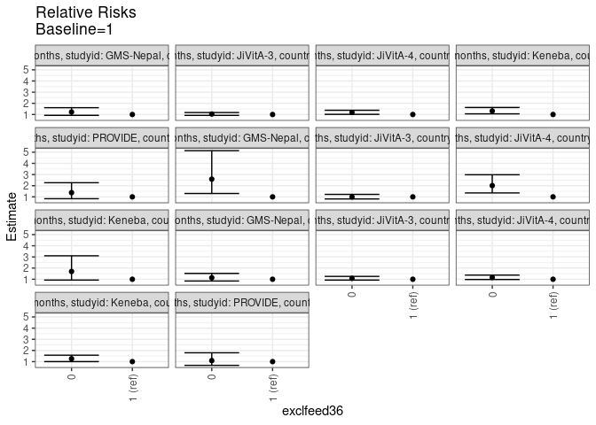

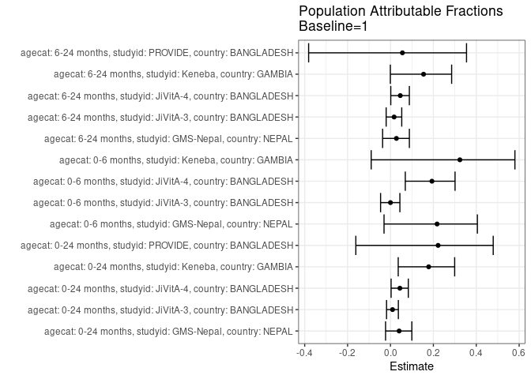

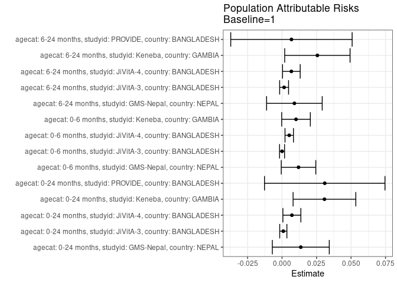

## Results Table

### Parameter: TSM

| agecat | studyid | country | intervention_level | baseline_level | estimate | ci_lower | ci_upper |
| --- | --- | --- | --- | --- | --- | --- | --- |
| 0-24 months | GMS-Nepal | NEPAL | 1 | NA | 0.3235333 | 0.2788517 | 0.3682149 |
| 0-24 months | GMS-Nepal | NEPAL | 0 | NA | 0.3941899 | 0.2994145 | 0.4889654 |
| 0-24 months | JiVitA-3 | BANGLADESH | 1 | NA | 0.0935439 | 0.0874222 | 0.0996655 |
| 0-24 months | JiVitA-3 | BANGLADESH | 0 | NA | 0.0972476 | 0.0865468 | 0.1079485 |
| 0-24 months | JiVitA-4 | BANGLADESH | 1 | NA | 0.1552298 | 0.1417780 | 0.1686817 |
| 0-24 months | JiVitA-4 | BANGLADESH | 0 | NA | 0.1835029 | 0.1590003 | 0.2080054 |
| 0-24 months | Keneba | GAMBIA | 1 | NA | 0.1417332 | 0.1150433 | 0.1684231 |
| 0-24 months | Keneba | GAMBIA | 0 | NA | 0.1859895 | 0.1655475 | 0.2064314 |
| 0-24 months | PROVIDE | BANGLADESH | 1 | NA | 0.1083440 | 0.0595587 | 0.1571293 |
| 0-24 months | PROVIDE | BANGLADESH | 0 | NA | 0.1491563 | 0.1171418 | 0.1811708 |
| 0-6 months | GMS-Nepal | NEPAL | 1 | NA | 0.0429895 | 0.0236888 | 0.0622901 |
| 0-6 months | GMS-Nepal | NEPAL | 0 | NA | 0.1111898 | 0.0536921 | 0.1686875 |
| 0-6 months | JiVitA-3 | BANGLADESH | 1 | NA | 0.0403334 | 0.0360876 | 0.0445792 |
| 0-6 months | JiVitA-3 | BANGLADESH | 0 | NA | 0.0402304 | 0.0331024 | 0.0473584 |
| 0-6 months | JiVitA-4 | BANGLADESH | 1 | NA | 0.0216760 | 0.0157156 | 0.0276363 |
| 0-6 months | JiVitA-4 | BANGLADESH | 0 | NA | 0.0435309 | 0.0305815 | 0.0564803 |
| 0-6 months | Keneba | GAMBIA | 1 | NA | 0.0211477 | 0.0097852 | 0.0325103 |
| 0-6 months | Keneba | GAMBIA | 0 | NA | 0.0358522 | 0.0259561 | 0.0457482 |
| 6-24 months | GMS-Nepal | NEPAL | 1 | NA | 0.3142493 | 0.2699087 | 0.3585899 |
| 6-24 months | GMS-Nepal | NEPAL | 0 | NA | 0.3562644 | 0.2638146 | 0.4487141 |
| 6-24 months | JiVitA-3 | BANGLADESH | 1 | NA | 0.0870246 | 0.0799603 | 0.0940889 |
| 6-24 months | JiVitA-3 | BANGLADESH | 0 | NA | 0.0936991 | 0.0805530 | 0.1068452 |
| 6-24 months | JiVitA-4 | BANGLADESH | 1 | NA | 0.1411603 | 0.1285794 | 0.1537411 |
| 6-24 months | JiVitA-4 | BANGLADESH | 0 | NA | 0.1635020 | 0.1397499 | 0.1872542 |
| 6-24 months | Keneba | GAMBIA | 1 | NA | 0.1403609 | 0.1125595 | 0.1681622 |
| 6-24 months | Keneba | GAMBIA | 0 | NA | 0.1764902 | 0.1561143 | 0.1968660 |
| 6-24 months | PROVIDE | BANGLADESH | 1 | NA | 0.1155357 | 0.0653914 | 0.1656799 |
| 6-24 months | PROVIDE | BANGLADESH | 0 | NA | 0.1260699 | 0.0957412 | 0.1563986 |

### Parameter: E(Y)

| agecat | studyid | country | intervention_level | baseline_level | estimate | ci_lower | ci_upper |
| --- | --- | --- | --- | --- | --- | --- | --- |
| 0-24 months | GMS-Nepal | NEPAL | NA | NA | 0.3371212 | 0.2967611 | 0.3774814 |
| 0-24 months | JiVitA-3 | BANGLADESH | NA | NA | 0.0944462 | 0.0888980 | 0.0999944 |
| 0-24 months | JiVitA-4 | BANGLADESH | NA | NA | 0.1623447 | 0.1503363 | 0.1743531 |
| 0-24 months | Keneba | GAMBIA | NA | NA | 0.1724660 | 0.1558341 | 0.1890978 |
| 0-24 months | PROVIDE | BANGLADESH | NA | NA | 0.1392801 | 0.1124135 | 0.1661468 |
| 0-6 months | GMS-Nepal | NEPAL | NA | NA | 0.0549242 | 0.0354725 | 0.0743760 |
| 0-6 months | JiVitA-3 | BANGLADESH | NA | NA | 0.0403270 | 0.0366289 | 0.0440252 |
| 0-6 months | JiVitA-4 | BANGLADESH | NA | NA | 0.0268722 | 0.0213332 | 0.0324113 |
| 0-6 months | Keneba | GAMBIA | NA | NA | 0.0312658 | 0.0236039 | 0.0389276 |
| 6-24 months | GMS-Nepal | NEPAL | NA | NA | 0.3231939 | 0.2831873 | 0.3632006 |
| 6-24 months | JiVitA-3 | BANGLADESH | NA | NA | 0.0885157 | 0.0819350 | 0.0950963 |
| 6-24 months | JiVitA-4 | BANGLADESH | NA | NA | 0.1479135 | 0.1367519 | 0.1590750 |
| 6-24 months | Keneba | GAMBIA | NA | NA | 0.1659664 | 0.1492505 | 0.1826823 |
| 6-24 months | PROVIDE | BANGLADESH | NA | NA | 0.1223491 | 0.0963874 | 0.1483108 |

### Parameter: RR

| agecat | studyid | country | intervention_level | baseline_level | estimate | ci_lower | ci_upper |
| --- | --- | --- | --- | --- | --- | --- | --- |
| 0-24 months | GMS-Nepal | NEPAL | 1 | 1 | 1.0000000 | 1.0000000 | 1.000000 |
| 0-24 months | GMS-Nepal | NEPAL | 0 | 1 | 1.2183905 | 0.9236656 | 1.607157 |
| 0-24 months | JiVitA-3 | BANGLADESH | 1 | 1 | 1.0000000 | 1.0000000 | 1.000000 |
| 0-24 months | JiVitA-3 | BANGLADESH | 0 | 1 | 1.0395938 | 0.9203900 | 1.174236 |
| 0-24 months | JiVitA-4 | BANGLADESH | 1 | 1 | 1.0000000 | 1.0000000 | 1.000000 |
| 0-24 months | JiVitA-4 | BANGLADESH | 0 | 1 | 1.1821364 | 1.0134012 | 1.378967 |
| 0-24 months | Keneba | GAMBIA | 1 | 1 | 1.0000000 | 1.0000000 | 1.000000 |
| 0-24 months | Keneba | GAMBIA | 0 | 1 | 1.3122506 | 1.0582290 | 1.627249 |
| 0-24 months | PROVIDE | BANGLADESH | 1 | 1 | 1.0000000 | 1.0000000 | 1.000000 |
| 0-24 months | PROVIDE | BANGLADESH | 0 | 1 | 1.3766916 | 0.8357694 | 2.267707 |
| 0-6 months | GMS-Nepal | NEPAL | 1 | 1 | 1.0000000 | 1.0000000 | 1.000000 |
| 0-6 months | GMS-Nepal | NEPAL | 0 | 1 | 2.5864424 | 1.3020985 | 5.137618 |
| 0-6 months | JiVitA-3 | BANGLADESH | 1 | 1 | 1.0000000 | 1.0000000 | 1.000000 |
| 0-6 months | JiVitA-3 | BANGLADESH | 0 | 1 | 0.9974464 | 0.8136971 | 1.222690 |
| 0-6 months | JiVitA-4 | BANGLADESH | 1 | 1 | 1.0000000 | 1.0000000 | 1.000000 |
| 0-6 months | JiVitA-4 | BANGLADESH | 0 | 1 | 2.0082564 | 1.3535674 | 2.979603 |
| 0-6 months | Keneba | GAMBIA | 1 | 1 | 1.0000000 | 1.0000000 | 1.000000 |
| 0-6 months | Keneba | GAMBIA | 0 | 1 | 1.6953197 | 0.9267617 | 3.101238 |
| 6-24 months | GMS-Nepal | NEPAL | 1 | 1 | 1.0000000 | 1.0000000 | 1.000000 |
| 6-24 months | GMS-Nepal | NEPAL | 0 | 1 | 1.1336998 | 0.8442783 | 1.522336 |
| 6-24 months | JiVitA-3 | BANGLADESH | 1 | 1 | 1.0000000 | 1.0000000 | 1.000000 |
| 6-24 months | JiVitA-3 | BANGLADESH | 0 | 1 | 1.0766967 | 0.9247800 | 1.253569 |
| 6-24 months | JiVitA-4 | BANGLADESH | 1 | 1 | 1.0000000 | 1.0000000 | 1.000000 |
| 6-24 months | JiVitA-4 | BANGLADESH | 0 | 1 | 1.1582725 | 0.9773662 | 1.372664 |
| 6-24 months | Keneba | GAMBIA | 1 | 1 | 1.0000000 | 1.0000000 | 1.000000 |
| 6-24 months | Keneba | GAMBIA | 0 | 1 | 1.2574029 | 1.0025250 | 1.577080 |
| 6-24 months | PROVIDE | BANGLADESH | 1 | 1 | 1.0000000 | 1.0000000 | 1.000000 |
| 6-24 months | PROVIDE | BANGLADESH | 0 | 1 | 1.0911774 | 0.6649598 | 1.790587 |

### Parameter: PAR

| agecat | studyid | country | intervention_level | baseline_level | estimate | ci_lower | ci_upper |
| --- | --- | --- | --- | --- | --- | --- | --- |
| 0-24 months | GMS-Nepal | NEPAL | 1 | NA | 0.0135879 | -0.0070515 | 0.0342273 |
| 0-24 months | JiVitA-3 | BANGLADESH | 1 | NA | 0.0009023 | -0.0016978 | 0.0035025 |
| 0-24 months | JiVitA-4 | BANGLADESH | 1 | NA | 0.0071149 | 0.0006035 | 0.0136263 |
| 0-24 months | Keneba | GAMBIA | 1 | NA | 0.0307328 | 0.0079992 | 0.0534664 |
| 0-24 months | PROVIDE | BANGLADESH | 1 | NA | 0.0309361 | -0.0127331 | 0.0746053 |
| 0-6 months | GMS-Nepal | NEPAL | 1 | NA | 0.0119348 | -0.0005907 | 0.0244603 |
| 0-6 months | JiVitA-3 | BANGLADESH | 1 | NA | -0.0000064 | -0.0018208 | 0.0018081 |
| 0-6 months | JiVitA-4 | BANGLADESH | 1 | NA | 0.0051963 | 0.0021322 | 0.0082604 |
| 0-6 months | Keneba | GAMBIA | 1 | NA | 0.0101180 | -0.0002630 | 0.0204991 |
| 6-24 months | GMS-Nepal | NEPAL | 1 | NA | 0.0089446 | -0.0112121 | 0.0291013 |
| 6-24 months | JiVitA-3 | BANGLADESH | 1 | NA | 0.0014911 | -0.0017340 | 0.0047161 |
| 6-24 months | JiVitA-4 | BANGLADESH | 1 | NA | 0.0067532 | 0.0003448 | 0.0131617 |
| 6-24 months | Keneba | GAMBIA | 1 | NA | 0.0256055 | 0.0019148 | 0.0492962 |
| 6-24 months | PROVIDE | BANGLADESH | 1 | NA | 0.0068134 | -0.0371994 | 0.0508263 |

### Parameter: PAF

| agecat | studyid | country | intervention_level | baseline_level | estimate | ci_lower | ci_upper |
| --- | --- | --- | --- | --- | --- | --- | --- |
| 0-24 months | GMS-Nepal | NEPAL | 1 | NA | 0.0403056 | -0.0229339 | 0.0996356 |
| 0-24 months | JiVitA-3 | BANGLADESH | 1 | NA | 0.0095538 | -0.0183672 | 0.0367093 |
| 0-24 months | JiVitA-4 | BANGLADESH | 1 | NA | 0.0438258 | 0.0028497 | 0.0831182 |
| 0-24 months | Keneba | GAMBIA | 1 | NA | 0.1781961 | 0.0360711 | 0.2993657 |
| 0-24 months | PROVIDE | BANGLADESH | 1 | NA | 0.2221144 | -0.1616046 | 0.4790775 |
| 0-6 months | GMS-Nepal | NEPAL | 1 | NA | 0.2172951 | -0.0300781 | 0.4052617 |
| 0-6 months | JiVitA-3 | BANGLADESH | 1 | NA | -0.0001581 | -0.0461772 | 0.0438367 |
| 0-6 months | JiVitA-4 | BANGLADESH | 1 | NA | 0.1933700 | 0.0690252 | 0.3011067 |
| 0-6 months | Keneba | GAMBIA | 1 | NA | 0.3236134 | -0.0899847 | 0.5802704 |
| 6-24 months | GMS-Nepal | NEPAL | 1 | NA | 0.0276756 | -0.0367432 | 0.0880918 |
| 6-24 months | JiVitA-3 | BANGLADESH | 1 | NA | 0.0168453 | -0.0201791 | 0.0525259 |
| 6-24 months | JiVitA-4 | BANGLADESH | 1 | NA | 0.0456566 | 0.0013748 | 0.0879748 |
| 6-24 months | Keneba | GAMBIA | 1 | NA | 0.1542814 | -0.0006432 | 0.2852198 |
| 6-24 months | PROVIDE | BANGLADESH | 1 | NA | 0.0556885 | -0.3817109 | 0.3546232 |